# Regresión Lineal Simple

10 de agosto de 2019

## Problema

## Descripción del problema

**Gasto militar vs Gasto en Educación:** previamente se evidenció a través de gráficos de dispersión y métricas de correlación, la relación negativa entre la inversión militar y la inversión en educación. Se sugiere construir un modelo de regresión lineal simple que permita determinar el cambio en \(y\) dado \(x\), es decir, que el modelo permitirá establecer por cada unidad que aumenta el gasto militar, cuánto disminuye el gasto en educación. El modelo se puede expresar de la siguiente manera:

- Modelo matemático: \(y = mx + b\)
- Modelo estadístico 1: \(y = \beta_0\ +\ \beta_1X\)
- Modelo estadístico 2: \(\hat{y_i} = \hat{\beta_0}\ + \hat{\beta_1}X_i\ + \epsilon_i\)

## Gasto Militar vs Gasto Educación

## Base de datos

| pais | gasto_militar17 | gasto_edu16 |
| --- | --- | --- |
| Afganistán | 0.9068569412 | 4.20525 |
| Albania | 1.2441751239 | 3.95464 |
| Argentina | 0.9096629933 | 5.57218 |
| Armenia | 3.9680393674 | 2.75812 |
| Azerbaiyán | 3.9373999369 | 2.90341 |
| Bangladesh | 1.3807504138 | 1.53554 |
| Belarús | 1.1919853143 | 4.94655 |
| Belice | 1.2530838896 | 7.06045 |
| Benin | 1.2163217396 | 3.99469 |
| Brunei Darussalam | 2.8792250162 | 4.42541 |

[output cut: 49 more lines]

## Histograma gasto militar

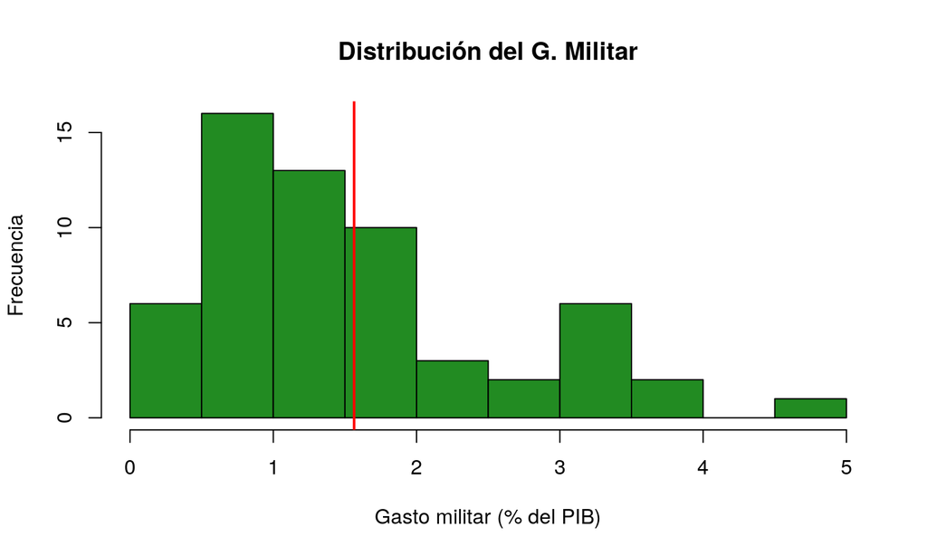

## Histograma gasto educación

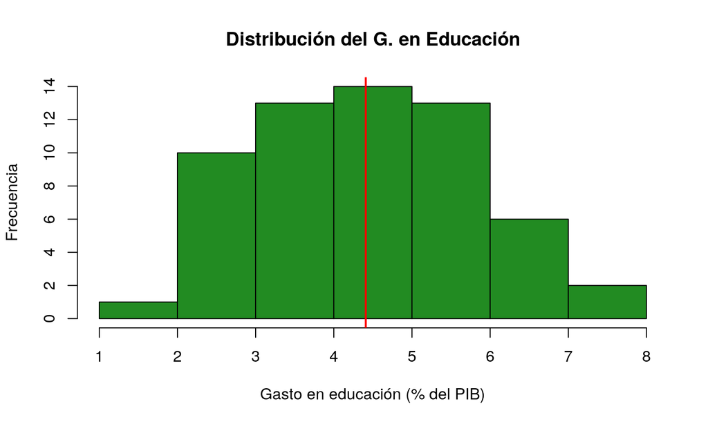

## Dispersión 1 (valor atípico)

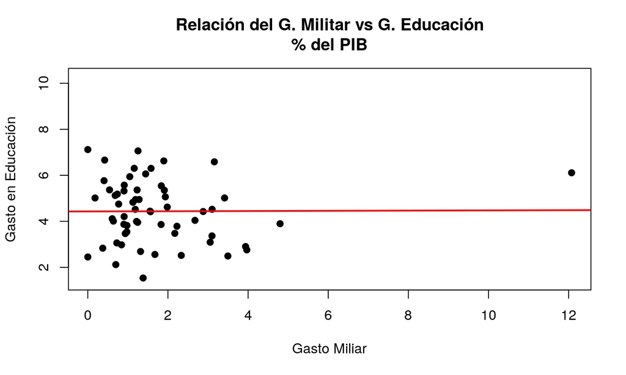

## Dispersión 2 (sin valor atípico)

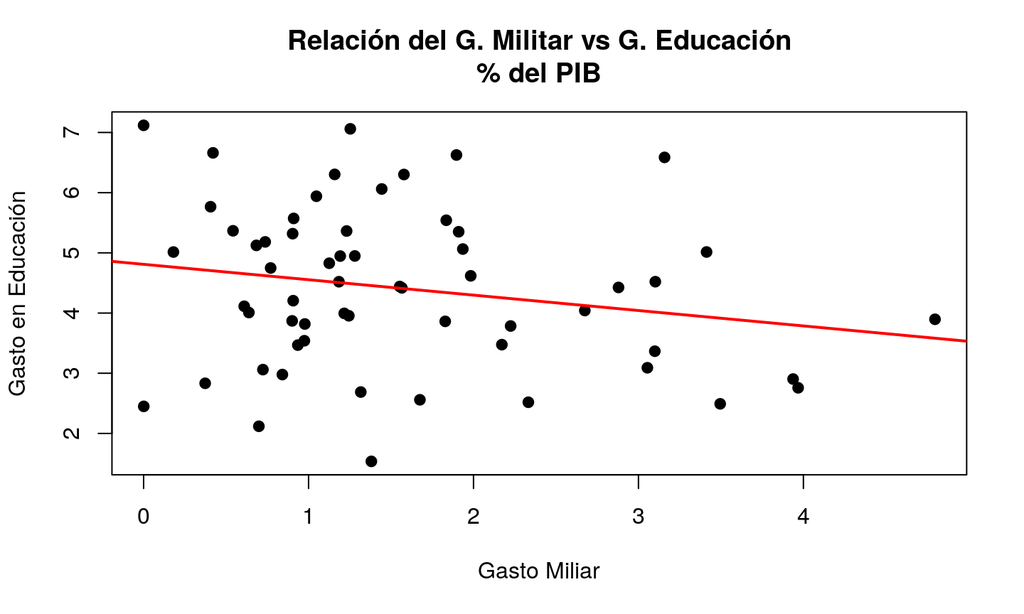

## Coeficientes de correlación

- **Correlación de Pearson con dato atípico:**

```
## [1] 0.005680844
```

- **Correlación de Pearson sin dato atípico:**

```
## [1] -0.2046813
```

## Test de hipótesis con valor atípico

\[H_0: \rho = 0\\H_1: \rho \neq 0\]

```
##
##  Pearson's product-moment correlation
##
## data:  datos$gasto_militar17 and datos$gasto_edu16
## t = 0.043265, df = 58, p-value = 0.9656
## alternative hypothesis: true correlation is not equal to 0
## 95 percent confidence interval:
##  -0.2486025  0.2592316
## sample estimates:
##         cor
## 0.005680844
```

**Conclusión:** como el valor p (0.9656) es mayor que el nivel de significancia \(\alpha = 0.05\), no existe evidencia para rechazar la hipótesis nula.

## Test de hipótesis sin valor atípico

\[H_0: \rho = 0\\H_1: \rho \neq 0\]

```
##
##  Pearson's product-moment correlation
##
## data:  df_reg$gasto_militar17 and df_reg$gasto_edu16
## t = -1.5787, df = 57, p-value = 0.1199
## alternative hypothesis: true correlation is not equal to 0
## 95 percent confidence interval:
##  -0.43781539  0.05424418
## sample estimates:
##        cor
## -0.2046813
```

**Conclusión:** como el valor p (0.1199) es mayor que el nivel de significancia \(\alpha = 0.05\), no existe evidencia para rechazar la hipótesis nula.

## Modelo tentativo

El modelo tentativo se puede expresar de la siguiente manera:

\[G.Edu = \beta_0\ +\ \beta_1G.Militar\]

## Regresión Lineal Simple en R

```
##
## Call:
## lm(formula = df_reg$gasto_edu16 ~ df_reg$gasto_militar17)
##
## Residuals:
##      Min       1Q   Median       3Q      Max
## -2.92035 -0.83829  0.02911  0.80882  2.58509
##
## Coefficients:
##                        Estimate Std. Error t value Pr(>|t|)
## (Intercept)              4.8092     0.3058  15.727   <2e-16 ***
## df_reg$gasto_militar17  -0.2559     0.1621  -1.579     0.12
## ---
## Signif. codes:  0 '***' 0.001 '**' 0.01 '*' 0.05 '.' 0.1 ' ' 1
##
## Residual standard error: 1.313 on 57 degrees of freedom
## Multiple R-squared:  0.04189,    Adjusted R-squared:  0.02509
## F-statistic: 2.492 on 1 and 57 DF,  p-value: 0.1199
```